# Lab 8 - Model Training and Evaluation

Author: Kevin Paganini  
Date: 2/5/2023  
Description: In this lab we are analyzing a stroke dataset. Included in the features we have an id, gender age, hypertension, heart_disease, ever_married, work_type, Residence_type, avg_glucose_level, bmi, smoking_status. Stroke is the dependent variable. Most variables are categorical, however we do have three features that are continuous. In this notebook I import the dataset, cleaned the dataset, did visualizations and statistical tests and then tried out various different models. Once I found the best model with the best combination of features I retrained this model on the entire dataset.

#### Imports and Setup

```python
import pandas as pd
import numpy as np
import matplotlib.pyplot as plt
import os
import seaborn as sns
import sys
import glob as gb
import json

pd.set_option('display.max_rows', 250)


# makes plots nice
def make_pretty(ax, title='', x_label='', y_label='', img=False):
    ax.set_title(title, fontsize=20)
    ax.set_xlabel(x_label, fontsize=16)
    ax.set_ylabel(y_label, fontsize=16)
    ax.legend(loc='best', fontsize=16)
    if img:
        ax.axis('off')
    return ax


stroke_path = os.path.join('Data', 'healthcare-dataset-stroke-data-1.csv')
```

The columns are as follows:  
• id: unique identifier  
• gender: "Male", "Female" or "Other"  
• age: age of the patient  
• hypertension: 0 if the patient doesn't have hypertension, 1 if the patient has  
hypertension  
• heart_disease: 0 if the patient doesn't have any heart diseases, 1 if the patient has a heart disease  
• ever_married: "No" or "Yes"  
• work_type: "children", "Govt_jov", "Never_worked", "Private" or "Self-employed"  
• Residence_type: "Rural" or "Urban"  
• avg_glucose_level: average glucose level in blood  
• bmi: body mass index  
• smoking_status: "formerly smoked", "never smoked", "smokes" or "Unknown"*  
• stroke: 1 if the patient had a stroke or 0 if not

## 1. Exploratory Data Analysis

It is likely smoking_status will be a good predictor of stroke. I also could see hypertension being a good predictor of strokes as well. I am unsure, but maybe there is a difference in male / female strokes. Maybe males tend to have more strokes than females. Heart_disease can be a good predictor as well. I think we have a lot of good date to work with here. I think a lot of the features here should have good association with stroke.

```python
df = pd.read_csv(stroke_path)
df.drop(['id'], axis=1, inplace=True)
df.head(10)
```

|  | gender | age | hypertension | heart_disease | ever_married | work_type | Residence_type | avg_glucose_level | bmi | smoking_status | stroke |
| --- | --- | --- | --- | --- | --- | --- | --- | --- | --- | --- | --- |
| 0 | Male | 67.0 | 0 | 1 | Yes | Private | Urban | 228.69 | 36.6 | formerly smoked | 1 |
| 1 | Female | 61.0 | 0 | 0 | Yes | Self-employed | Rural | 202.21 | NaN | never smoked | 1 |
| 2 | Male | 80.0 | 0 | 1 | Yes | Private | Rural | 105.92 | 32.5 | never smoked | 1 |
| 3 | Female | 49.0 | 0 | 0 | Yes | Private | Urban | 171.23 | 34.4 | smokes | 1 |
| 4 | Female | 79.0 | 1 | 0 | Yes | Self-employed | Rural | 174.12 | 24.0 | never smoked | 1 |
| 5 | Male | 81.0 | 0 | 0 | Yes | Private | Urban | 186.21 | 29.0 | formerly smoked | 1 |
| 6 | Male | 74.0 | 1 | 1 | Yes | Private | Rural | 70.09 | 27.4 | never smoked | 1 |
| 7 | Female | 69.0 | 0 | 0 | No | Private | Urban | 94.39 | 22.8 | never smoked | 1 |
| 8 | Female | 59.0 | 0 | 0 | Yes | Private | Rural | 76.15 | NaN | Unknown | 1 |
| 9 | Female | 78.0 | 0 | 0 | Yes | Private | Urban | 58.57 | 24.2 | Unknown | 1 |

```python
df['gender'] = df['gender'].astype('category')
df['age'] = df['age'].astype('int')
df['hypertension'] = df['hypertension'].astype('bool')
df['heart_disease'] = df['heart_disease'].astype('bool')
df['ever_married'] = df['ever_married'].astype('category')
df['work_type'] = df['work_type'].astype('category')
df['Residence_type'] = df['Residence_type'].astype('category')
df['smoking_status'] = df['smoking_status'].astype('category')
df['stroke'] = df['stroke'].astype('bool')


df.info()
```

```
<class 'pandas.core.frame.DataFrame'>
RangeIndex: 5110 entries, 0 to 5109
Data columns (total 11 columns):
 #   Column             Non-Null Count  Dtype
---  ------             --------------  -----
 0   gender             5110 non-null   category
 1   age                5110 non-null   int32
 2   hypertension       5110 non-null   bool
 3   heart_disease      5110 non-null   bool
 4   ever_married       5110 non-null   category
 5   work_type          5110 non-null   category
 6   Residence_type     5110 non-null   category
 7   avg_glucose_level  5110 non-null   float64
 8   bmi                4909 non-null   float64
 9   smoking_status     5110 non-null   category
 10  stroke             5110 non-null   bool
dtypes: bool(3), category(5), float64(2), int32(1)
memory usage: 140.6 KB
```

```python
df.describe()
```

|  | age | avg_glucose_level | bmi |
| --- | --- | --- | --- |
| count | 5110.000000 | 5110.000000 | 4909.000000 |
| mean | 43.215264 | 106.147677 | 28.893237 |
| std | 22.633866 | 45.283560 | 7.854067 |
| min | 0.000000 | 55.120000 | 10.300000 |
| 25% | 25.000000 | 77.245000 | 23.500000 |
| 50% | 45.000000 | 91.885000 | 28.100000 |
| 75% | 61.000000 | 114.090000 | 33.100000 |
| max | 82.000000 | 271.740000 | 97.600000 |

```python
df.head()
```

|  | gender | age | hypertension | heart_disease | ever_married | work_type | Residence_type | avg_glucose_level | bmi | smoking_status | stroke |
| --- | --- | --- | --- | --- | --- | --- | --- | --- | --- | --- | --- |
| 0 | Male | 67 | False | True | Yes | Private | Urban | 228.69 | 36.6 | formerly smoked | True |
| 1 | Female | 61 | False | False | Yes | Self-employed | Rural | 202.21 | NaN | never smoked | True |
| 2 | Male | 80 | False | True | Yes | Private | Rural | 105.92 | 32.5 | never smoked | True |
| 3 | Female | 49 | False | False | Yes | Private | Urban | 171.23 | 34.4 | smokes | True |
| 4 | Female | 79 | True | False | Yes | Self-employed | Rural | 174.12 | 24.0 | never smoked | True |

### Distributions of all features

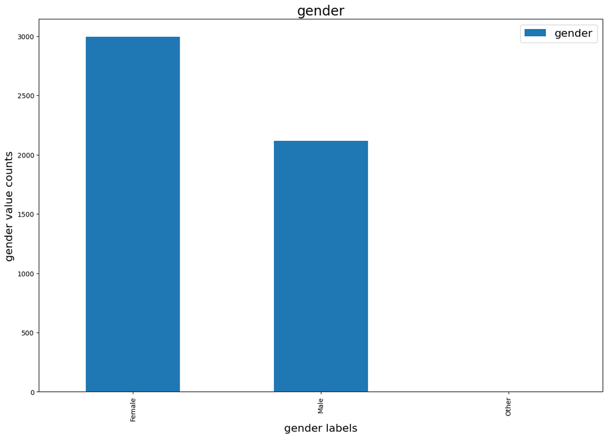

```python
def make_bar(ax, col, df):
    vc = df[col].value_counts()

    ax = vc.plot(kind='bar', ax=ax)
    make_pretty(ax, col, f'{col} labels', f'{col} value counts')
    return ax


fig, ax = plt.subplots(figsize=(15, 10))


make_bar(ax, 'gender', df)
```

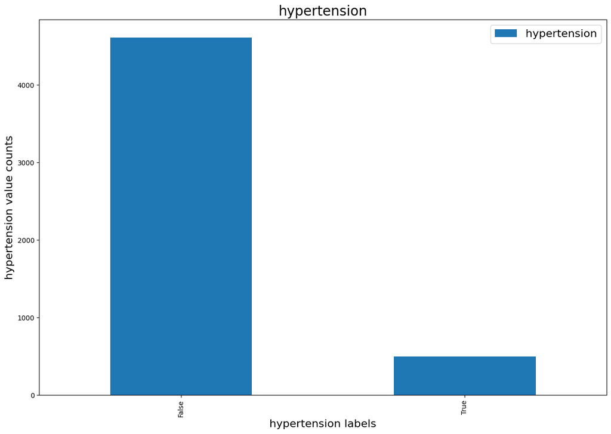

```python
fig, ax = plt.subplots(figsize=(15, 10))

make_bar(ax, 'hypertension', df)
```

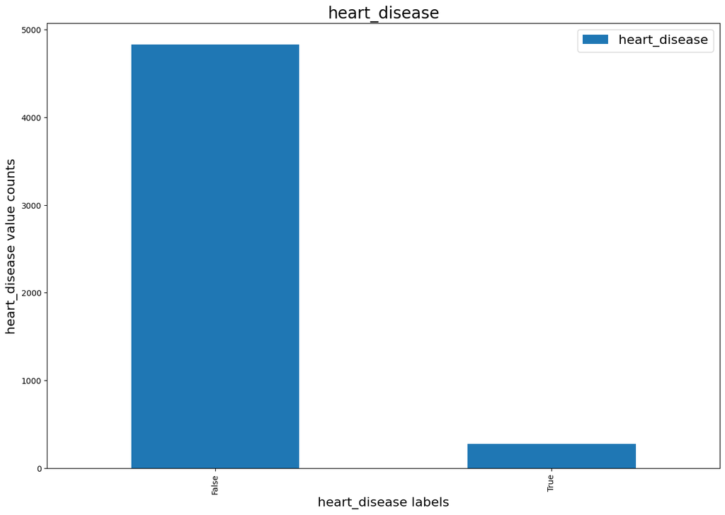

```python
fig, ax = plt.subplots(figsize=(15, 10))

make_bar(ax, 'heart_disease', df)
```

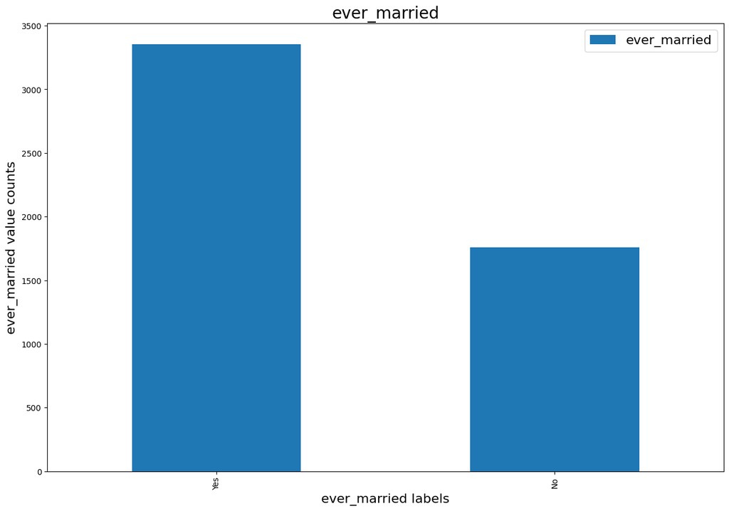

```python
fig, ax = plt.subplots(figsize=(15, 10))
make_bar(ax, 'ever_married', df)
```

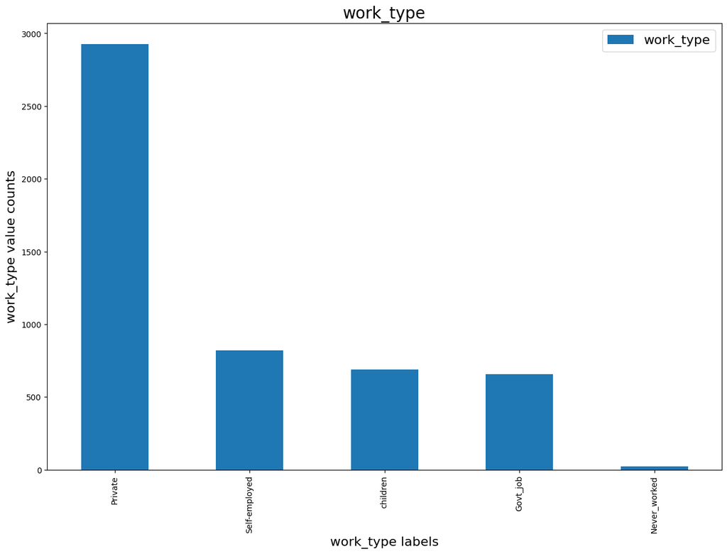

```python
fig, ax = plt.subplots(figsize=(15, 10))

make_bar(ax, 'work_type', df)
```

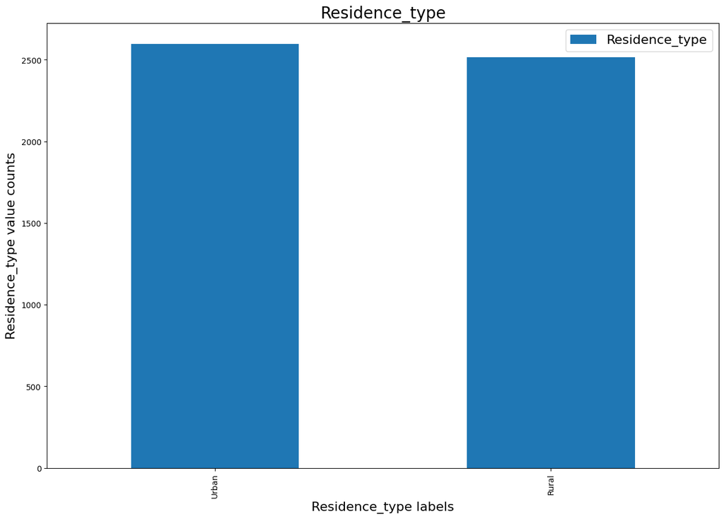

```python
fig, ax = plt.subplots(figsize=(15, 10))

make_bar(ax, 'Residence_type', df)
```

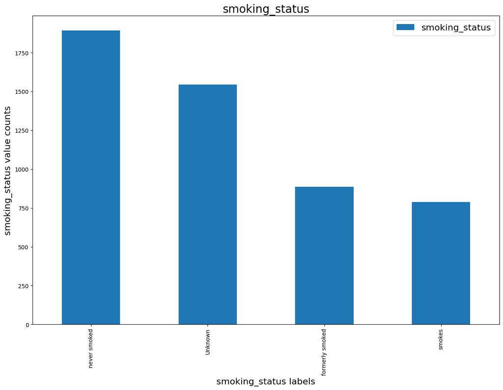

```python
fig, ax = plt.subplots(figsize=(15, 10))

make_bar(ax, 'smoking_status', df)
```

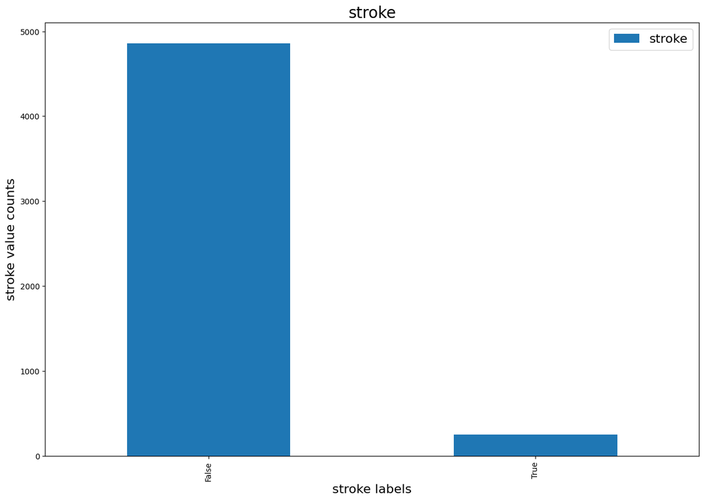

```python
fig, ax = plt.subplots(figsize=(15, 10))

make_bar(ax, 'stroke', df)
```

Very uneven dataset as seen here.

```
Min of age: 0
Max of age: 82
```

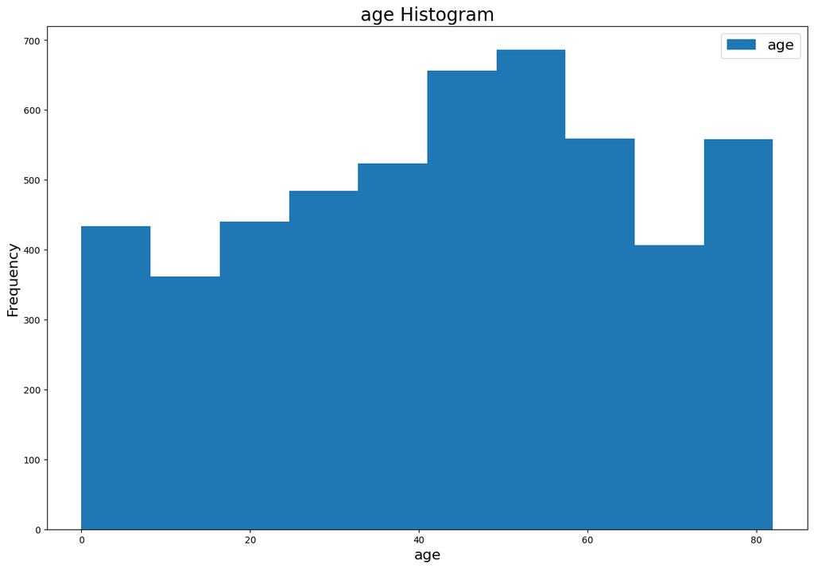

```python
def make_hist(ax, col, df):
    print(f'Min of {col}: {df[col].min()}')
    print(f'Max of {col}: {df[col].max()}')
    ax = df[col].plot(kind='hist', ax=ax)
    make_pretty(ax, f'{col} Histogram', col, 'Frequency')


fig, ax = plt.subplots(figsize=(15, 10))

make_hist(ax, 'age', df)
```

```
Min of bmi: 10.3
Max of bmi: 97.6
```

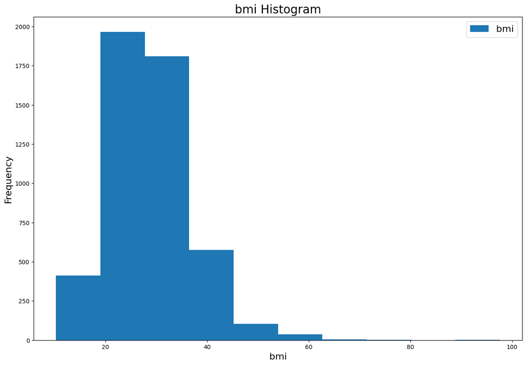

```python
fig, ax = plt.subplots(figsize=(15, 10))

make_hist(ax, 'bmi', df)
```

BMI follows a relatively normal distribution as well with a tail towards the higher end

```
Min of avg_glucose_level: 55.12
Max of avg_glucose_level: 271.74
```

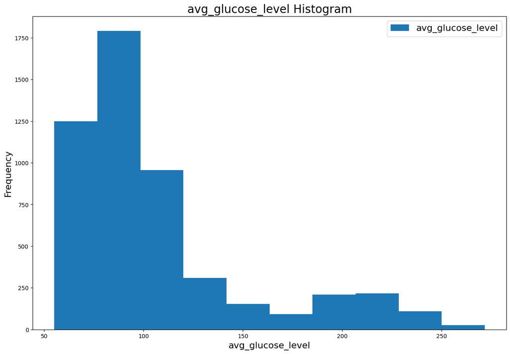

```python
fig, ax = plt.subplots(figsize=(15, 10))

make_hist(ax, 'avg_glucose_level', df)
```

### Exploring relationships between variables and target variable (stroke)

```
[Text(1, 0, 'Stroke'), Text(2, 0, 'No Stroke')]
```

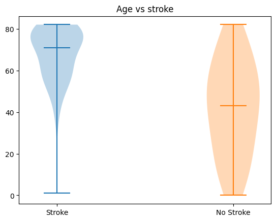

```python
fig, ax = plt.subplots()

ax.violinplot(df['age'][df['stroke'] == 1], showmedians=True, showextrema=True, positions=[1], widths=0.3,bw_method=0.5)
ax.violinplot(df['age'][df['stroke'] == 0], showmedians=True, showextrema=True, positions=[2], widths=0.3, bw_method=0.5)
ax.set_title('Age vs stroke')
ax.set_xticks([1, 2])
ax.set_xticklabels(['Stroke', 'No Stroke'])
```

```
[Text(1, 0, 'Stroke'), Text(2, 0, 'No Stroke')]
```

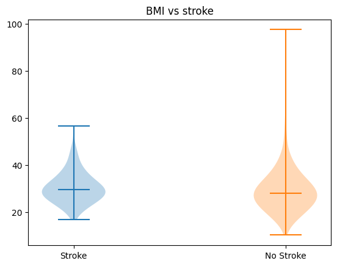

```python
fig, ax = plt.subplots()
temp = df.dropna()
ax.violinplot(temp['bmi'][temp['stroke'] == 1], showmedians=True, showextrema=True, positions=[1], widths=0.3,bw_method=0.5)
ax.violinplot(temp['bmi'][temp['stroke'] == 0], showmedians=True, showextrema=True, positions=[2], widths=0.3, bw_method=0.5)
ax.set_title('BMI vs stroke')
ax.set_xticks([1, 2])
ax.set_xticklabels(['Stroke', 'No Stroke'])
```

```
[Text(1, 0, 'Stroke'), Text(2, 0, 'No Stroke')]
```

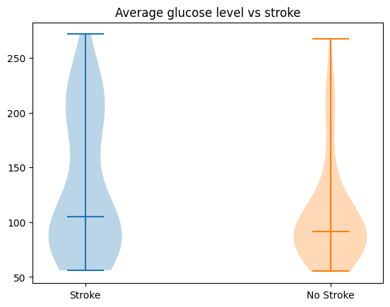

```python
fig, ax = plt.subplots()

ax.violinplot(df['avg_glucose_level'][df['stroke'] == 1], showmedians=True, showextrema=True, positions=[1], widths=0.3,bw_method=0.5)
ax.violinplot(df['avg_glucose_level'][df['stroke'] == 0], showmedians=True, showextrema=True, positions=[2], widths=0.3, bw_method=0.5)
ax.set_title('Average glucose level vs stroke')
ax.set_xticks([1, 2])
ax.set_xticklabels(['Stroke', 'No Stroke'])
```

```
No artists with labels found to put in legend.  Note that artists whose label start with an underscore are ignored when legend() is called with no argument.
```

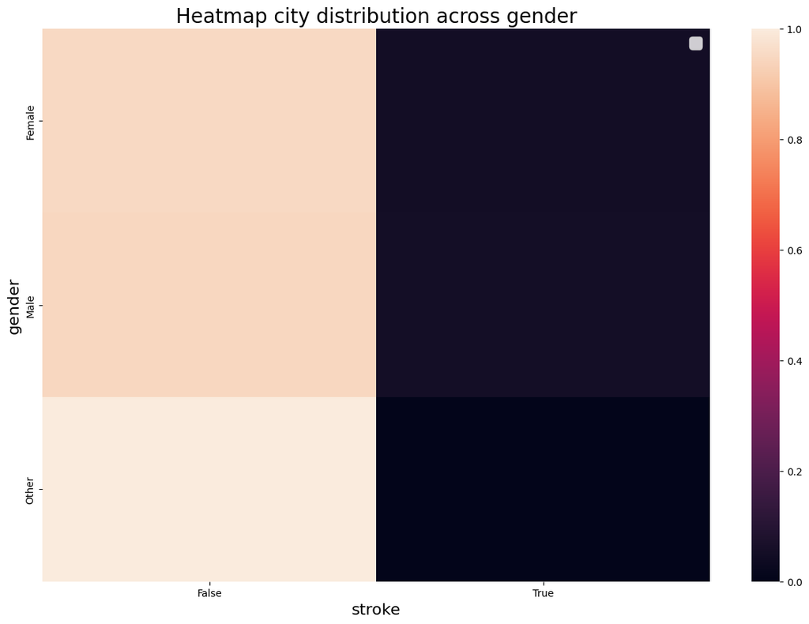

```python
fig, ax = plt.subplots(figsize=(15, 10))

sns.heatmap(pd.crosstab(df['gender'], df['stroke'], normalize='index'), xticklabels=True, yticklabels=True, ax=ax)
make_pretty(ax, 'Heatmap city distribution across gender', 'stroke', 'gender')
```

```
No artists with labels found to put in legend.  Note that artists whose label start with an underscore are ignored when legend() is called with no argument.
```

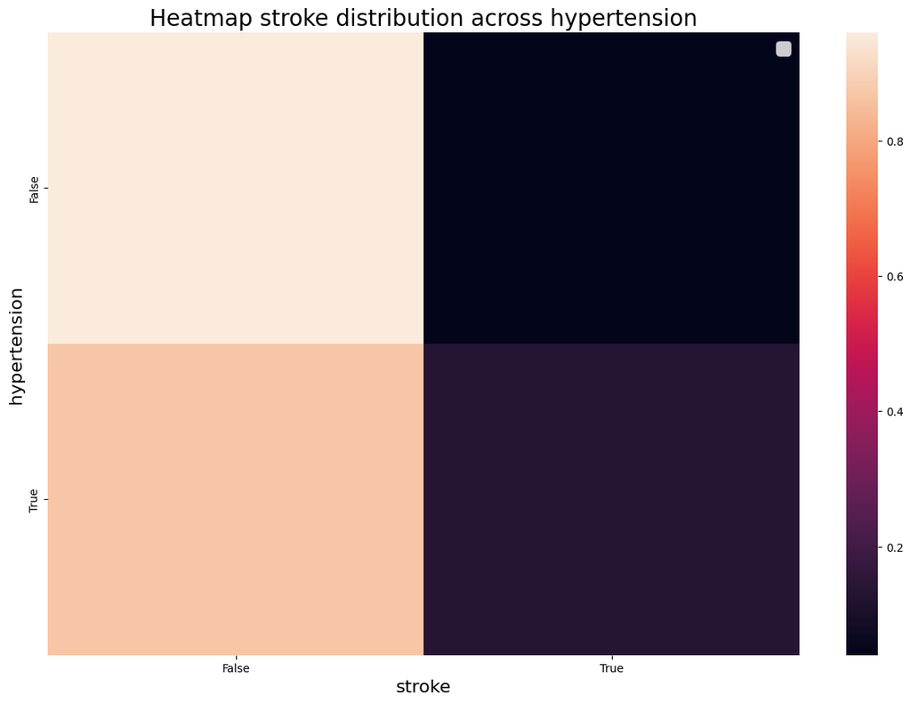

```python
fig, ax = plt.subplots(figsize=(15, 10))

sns.heatmap(pd.crosstab(df['hypertension'], df['stroke'], normalize='index'), xticklabels=True, yticklabels=True, ax=ax)
make_pretty(ax, 'Heatmap stroke distribution across hypertension', 'stroke', 'hypertension')
```

```
No artists with labels found to put in legend.  Note that artists whose label start with an underscore are ignored when legend() is called with no argument.
```

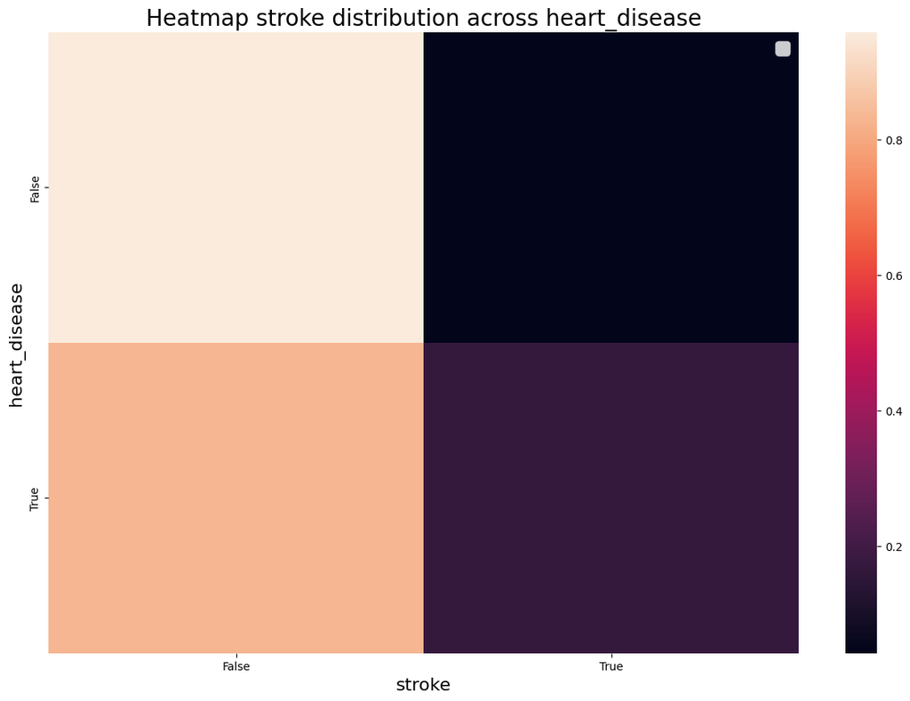

```python
fig, ax = plt.subplots(figsize=(15, 10))

sns.heatmap(pd.crosstab(df['heart_disease'], df['stroke'], normalize='index'), xticklabels=True, yticklabels=True, ax=ax)
make_pretty(ax, 'Heatmap stroke distribution across heart_disease', 'stroke', 'heart_disease')
```

```
No artists with labels found to put in legend.  Note that artists whose label start with an underscore are ignored when legend() is called with no argument.
```

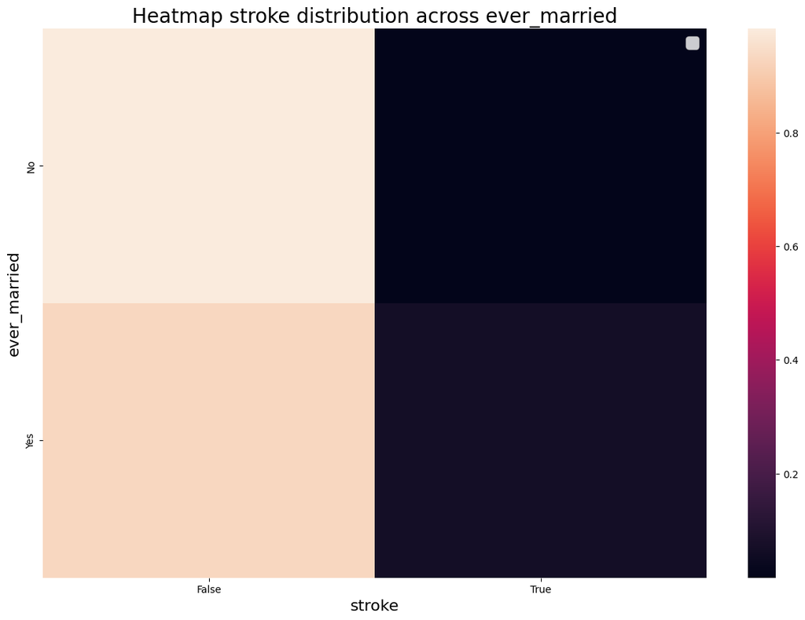

```python
fig, ax = plt.subplots(figsize=(15, 10))

sns.heatmap(pd.crosstab(df['ever_married'], df['stroke'], normalize='index'), xticklabels=True, yticklabels=True, ax=ax)
make_pretty(ax, 'Heatmap stroke distribution across ever_married', 'stroke', 'ever_married')
```

```
No artists with labels found to put in legend.  Note that artists whose label start with an underscore are ignored when legend() is called with no argument.
```

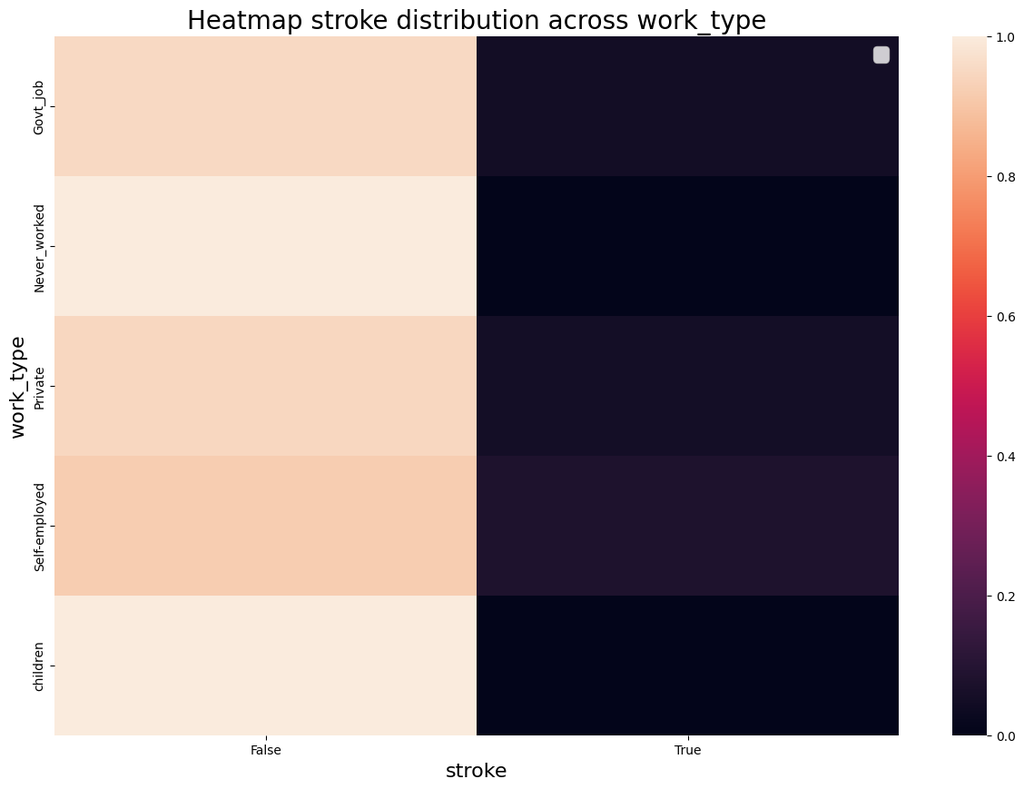

```python
fig, ax = plt.subplots(figsize=(15, 10))

sns.heatmap(pd.crosstab(df['work_type'], df['stroke'], normalize='index'), xticklabels=True, yticklabels=True, ax=ax)
make_pretty(ax, 'Heatmap stroke distribution across work_type', 'stroke', 'work_type')
```

```
No artists with labels found to put in legend.  Note that artists whose label start with an underscore are ignored when legend() is called with no argument.
```

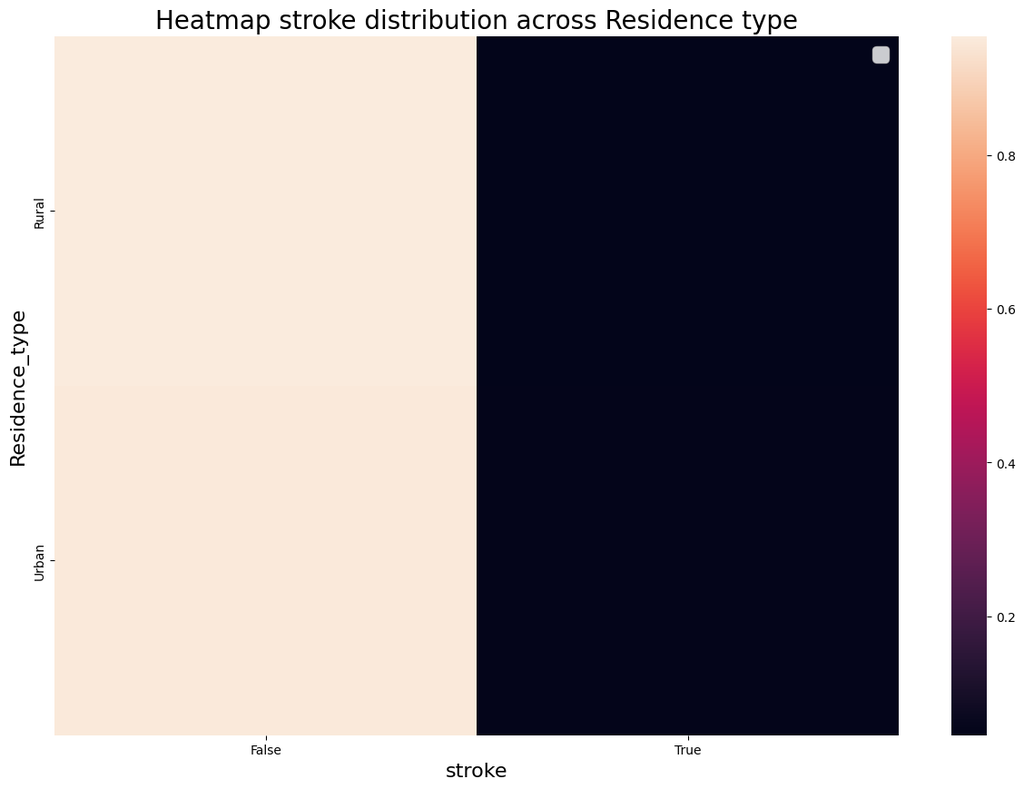

```python
fig, ax = plt.subplots(figsize=(15, 10))

sns.heatmap(pd.crosstab(df['Residence_type'], df['stroke'], normalize='index'), xticklabels=True, yticklabels=True, ax=ax)
make_pretty(ax, 'Heatmap stroke distribution across Residence type', 'stroke', 'Residence_type')
```

```
No artists with labels found to put in legend.  Note that artists whose label start with an underscore are ignored when legend() is called with no argument.
```

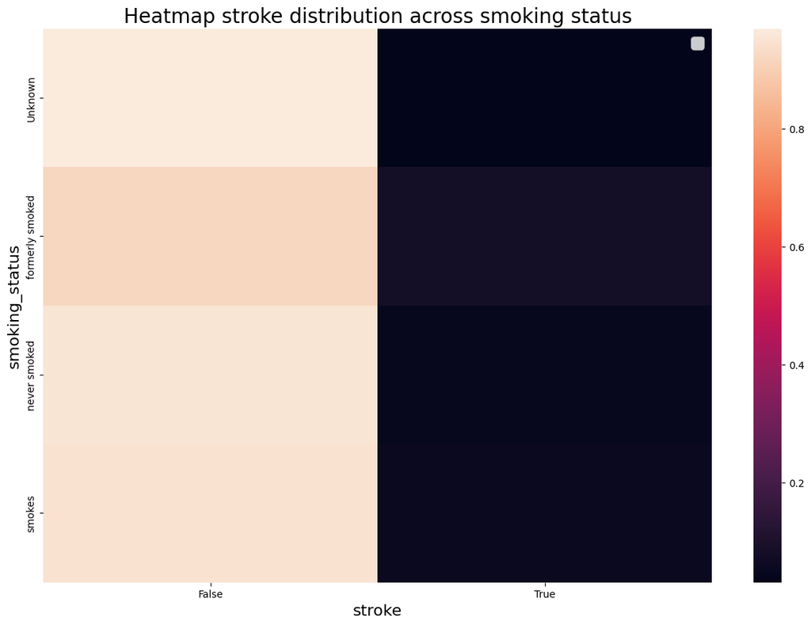

```python
fig, ax = plt.subplots(figsize=(15, 10))

sns.heatmap(pd.crosstab(df['smoking_status'], df['stroke'], normalize='index'), xticklabels=True, yticklabels=True, ax=ax)
make_pretty(ax, 'Heatmap stroke distribution across smoking status', 'stroke', 'smoking_status')
```

### Statistical Tests

```python
from scipy.stats import kruskal


cont_var = ['avg_glucose_level', 'bmi', 'age']


for x in cont_var:
    samples_by_group = []
    for y in set(df['stroke']):
        mask = df['stroke'] == y
        samples_by_group.append(df[x][mask])
    stat, p = kruskal(*samples_by_group, nan_policy='omit')




    print(f'{x} p: {p}')
    print(f'{x} stat: {stat}')
```

```
avg_glucose_level p: 3.639881441958809e-09
avg_glucose_level stat: 34.80739568673386
bmi p: 0.00010263237377217097
bmi stat: 15.087653240803583
age p: 3.695033198300678e-71
age stat: 318.13281444188146
```

Interestingly enough bmi has the highest p value.

```python
from scipy.stats import chi2_contingency

cat_vars = ['gender', 'hypertension', 'heart_disease', 'ever_married', 'work_type', 'Residence_type', 'smoking_status']



for val in cat_vars:
    comb_counts = pd.crosstab(df[val], df['stroke'])
    chi2, p, _, _ = chi2_contingency(comb_counts)

    print(f'{val} chi2: {chi2}')
    print(f'{val} p: {p}')
```

```
gender chi2: 0.47258662884530234
gender p: 0.7895490538408245
hypertension chi2: 81.6053682482931
hypertension p: 1.661621901511823e-19
heart_disease chi2: 90.25956125843324
heart_disease p: 2.0887845685229236e-21
ever_married chi2: 58.923890259034195
ever_married p: 1.6389021142314745e-14
work_type chi2: 49.163511976675295
work_type p: 5.397707801896119e-10
Residence_type chi2: 1.0816367471627524
Residence_type p: 0.29833169286876987
smoking_status chi2: 29.147269191399264
smoking_status p: 2.0853997025008455e-06
```

Gender and Residence_type have high p values while the others do not.

### 2. Train-Test Split

```python
features = df[df.columns[0:-1]]
features.head()
```

|  | gender | age | hypertension | heart_disease | ever_married | work_type | Residence_type | avg_glucose_level | bmi | smoking_status |
| --- | --- | --- | --- | --- | --- | --- | --- | --- | --- | --- |
| 0 | Male | 67 | False | True | Yes | Private | Urban | 228.69 | 36.6 | formerly smoked |
| 1 | Female | 61 | False | False | Yes | Self-employed | Rural | 202.21 | NaN | never smoked |
| 2 | Male | 80 | False | True | Yes | Private | Rural | 105.92 | 32.5 | never smoked |
| 3 | Female | 49 | False | False | Yes | Private | Urban | 171.23 | 34.4 | smokes |
| 4 | Female | 79 | True | False | Yes | Self-employed | Rural | 174.12 | 24.0 | never smoked |

```python
target = df[['stroke']]
target.head()
```

|  | stroke |
| --- | --- |
| 0 | True |
| 1 | True |
| 2 | True |
| 3 | True |
| 4 | True |

```python
target.value_counts()
```

```
stroke
False     4861
True       249
dtype: int64
```

```python
from sklearn.model_selection import train_test_split

X_train, X_test, y_train, y_test = train_test_split(features, target, test_size=0.2, random_state=42)
print(f'X train shape: {X_train.shape}')
print(f'X test shape: {X_test.shape}')
y_train = y_train.values.ravel()
y_test = y_test.values.ravel()
```

```
X train shape: (4088, 10)
X test shape: (1022, 10)
```

### 3. Choice of evaluation metric and baseline model

Since both false negatives and false positives are both costly, we want to use a metric that takes both into account. Therefore, I will be using the f1-score. The f1-score is the harmonic mean of the precision and recall. 2 * (precision * recall) / (precision + recall)

#### Making a dummy classifier

```python
from sklearn.dummy import DummyClassifier
from sklearn.metrics import f1_score

dummy = DummyClassifier(strategy='constant', constant=1)
dummy.fit(X_train, y_train)
f1_score(y_train, dummy.predict(X_train))
```

```
0.08748538011695906
```

Gotta beat an f1 score of 0.087 for it to actually be doing something.

### Making a preprocessing pipeline

```python
from sklearn.pipeline import Pipeline
from sklearn.impute import SimpleImputer
from sklearn.preprocessing import StandardScaler
from sklearn.compose import ColumnTransformer
from sklearn.preprocessing import OneHotEncoder
from sklearn.linear_model import LogisticRegression


num_attribs = ['age', 'bmi', 'avg_glucose_level']
cat_attribs = ['gender', 'hypertension', 'heart_disease', 'ever_married', 'work_type', 'Residence_type', 'smoking_status']


num_pipeline = Pipeline([
    ('imputer', SimpleImputer(strategy='median')),
    ('std_scaler', StandardScaler())
])

full_pipe = Pipeline([
    ('preprocessor', ColumnTransformer([
        ('num', num_pipeline, num_attribs),
        ('cat', OneHotEncoder(), cat_attribs)
    ]))
])
```

```python
full_pipe_log_reg = Pipeline([('full_pipe', full_pipe), ('log_reg', LogisticRegression(solver='lbfgs', max_iter=1000, penalty='l2', C=1.0))])
```

```python
from sklearn.metrics import f1_score

full_pipe_log_reg.fit(X_train, y_train)
predictions = full_pipe_log_reg.predict(X_train)
f1_score(y_train, predictions)
```

```
0.010638297872340425
```

```python
from sklearn.naive_bayes import GaussianNB
from sklearn.ensemble import RandomForestClassifier

full_pipe_naive_bayes = Pipeline([('full_pipe', full_pipe), ('clf', GaussianNB())])
full_pipe_rand_forest = Pipeline([('full_pipe', full_pipe), ('clf', RandomForestClassifier())])
full_pipe_log_reg_class_weighted = Pipeline([('full_pipe', full_pipe), ('clf', LogisticRegression(class_weight='balanced'))])
```

```python
from sklearn.model_selection import cross_validate

result_log_reg = cross_validate(full_pipe_log_reg, X_train, y_train, cv=5, scoring='f1')
result_naive_bayes = cross_validate(full_pipe_naive_bayes, X_train, y_train, cv=5, scoring='f1')
result_rand_forest = cross_validate(full_pipe_rand_forest, X_train, y_train, cv=5, scoring='f1')
result_log_reg_class_weighted = cross_validate(full_pipe_log_reg_class_weighted, X_train, y_train, cv=5, scoring='f1')
```

```python
t = 'test_score'
print(f'Average f1-score: {np.mean(result_log_reg[t])}')
result_log_reg
```

```
Average f1-score: 0.010256410256410258
```

```
{'fit_time': array([0.03646469, 0.02700233, 0.02741623, 0.02571654, 0.02985096]),
 'score_time': array([0.00504088, 0.00500083, 0.0049994 , 0.00602007, 0.00510359]),
 'test_score': array([0.05128205, 0.        , 0.        , 0.        , 0.        ])}
```

```python
print(f'Average f1-score: {np.mean(result_naive_bayes[t])}')
result_naive_bayes
```

```
Average f1-score: 0.12448830952564213
```

```
{'fit_time': array([0.01101232, 0.01109314, 0.01281238, 0.0109942 , 0.00999975]),
 'score_time': array([0.00417256, 0.00417709, 0.00652909, 0.0051899 , 0.00503826]),
 'test_score': array([0.12698413, 0.1208981 , 0.12371134, 0.12765957, 0.12318841])}
```

```python
print(f'Average f1-score: {np.mean(result_rand_forest[t])}')
result_rand_forest
```

```
Average f1-score: 0.019780219780219783
```

```
{'fit_time': array([0.24492264, 0.25868964, 0.31214237, 0.2511189 , 0.24525905]),
 'score_time': array([0.01787448, 0.01926279, 0.01749659, 0.01658821, 0.01565433]),
 'test_score': array([0.        , 0.        , 0.04761905, 0.        , 0.05128205])}
```

```python
print(f'Average f1-score: {np.mean(result_log_reg_class_weighted[t])}')
result_log_reg_class_weighted
```

```
Average f1-score: 0.2151053678473215
```

```
{'fit_time': array([0.0319221 , 0.02756095, 0.02916908, 0.03016138, 0.03135157]),
 'score_time': array([0.00513887, 0.0060184 , 0.00501728, 0.00500083, 0.00597239]),
 'test_score': array([0.18115942, 0.2260274 , 0.20833333, 0.22834646, 0.23166023])}
```

### 7. Feature Selection - greedy Approach

```python
transformed_features = full_pipe.fit_transform(X_train, y_train)
transformed_features[0]
```

```
array([ 1.58322417, -0.05360734,  0.13559307,  0.        ,  1.        ,
        1.        ,  0.        ,  1.        ,  0.        ,  0.        ,
        1.        ,  0.        ,  0.        ,  0.        ,  1.        ,
        0.        ,  1.        ,  0.        ,  0.        ,  1.        ,
        0.        ,  0.        ])
```

```python
age = cross_validate(LogisticRegression(class_weight='balanced'), transformed_features[:,0:1], y_train, cv=5, scoring='f1')
bmi = cross_validate(LogisticRegression(class_weight='balanced'), transformed_features[:,1:2], y_train, cv=5, scoring='f1')
avg_glucose_level = cross_validate(LogisticRegression(class_weight='balanced'), transformed_features[:,2:3], y_train, cv=5, scoring='f1')
gender = cross_validate(LogisticRegression(class_weight='balanced'), transformed_features[:,3:5], y_train, cv=5, scoring='f1')

hypertension = cross_validate(LogisticRegression(class_weight='balanced'), transformed_features[:,5:7], y_train, cv=5, scoring='f1')

heart_disease = cross_validate(LogisticRegression(class_weight='balanced'), transformed_features[:,7:9], y_train, cv=5, scoring='f1')

married = cross_validate(LogisticRegression(class_weight='balanced'), transformed_features[:,9:11], y_train, cv=5, scoring='f1')
job = cross_validate(LogisticRegression(class_weight='balanced'), transformed_features[:,10:15], y_train, cv=5, scoring='f1')
house = cross_validate(LogisticRegression(class_weight='balanced'), transformed_features[:,15:17], y_train, cv=5, scoring='f1')
smoking = cross_validate(LogisticRegression(class_weight='balanced'), transformed_features[:,17:22], y_train, cv=5, scoring='f1')
```

```python
df['smoking_status'].value_counts()
```

```
never smoked       1892
Unknown            1544
formerly smoked     885
smokes              789
Name: smoking_status, dtype: int64
```

```python
best = 0
count = 1
scores = []
lgs = [age, bmi, avg_glucose_level, gender, hypertension, heart_disease, married, job, house, smoking]
lgs_names = ['age', 'bmi', 'avg_glucose_level', 'gender', 'hypertension', 'heart_disease', 'married', 'job', 'house', 'smoking']
for lg in lgs:
    scores.append(np.mean(lg['test_score']))

ret = np.argsort(scores)
ret = ret
print(f'Best indices sorted in lowest score to highest score: {ret}')
for i in ret:
    print(f'{lgs_names[i]} : {scores[i]}')
```

```
Best indices sorted in lowest score to highest score: [3 1 8 9 6 7 2 4 5 0]
gender : 0.07874498879262752
bmi : 0.09035729884811504
house : 0.09903264026049265
smoking : 0.10428190690372947
married : 0.11319648854973144
job : 0.11319648854973144
avg_glucose_level : 0.1399631747089374
hypertension : 0.16447332077840554
heart_disease : 0.1727485577200225
age : 0.2038902854799042
```

0 (age) is the best feature

```python
feat1 = transformed_features[:,0:1]
feat2 = transformed_features[:,7:9]
feat3 = transformed_features[:,5:7]
feat4 = transformed_features[:,2:3]
feat5 = transformed_features[:,10:15]
feat6 = transformed_features[:,9:11]
feat7 = transformed_features[:,17:22]
feat8 = transformed_features[:,15:17]
feat9 = transformed_features[:,1:2]
feat10 = transformed_features[:,3:5]
```

```python
lg1_feat = cross_validate(LogisticRegression(class_weight='balanced'), feat1, y_train, cv=5, scoring='f1')
np.mean(lg1_feat['test_score'])
```

```
0.2038902854799042
```

```python
feat_stack = np.hstack([feat1, feat2])
lg2_feat = cross_validate(LogisticRegression(class_weight='balanced'), feat_stack, y_train, cv=5, scoring='f1')
np.mean(lg2_feat['test_score'])
```

```
0.20603116720587708
```

```python
feat_stack = np.hstack([feat1, feat2, feat3])
lg3_feat = cross_validate(LogisticRegression(class_weight='balanced'), feat_stack, y_train, cv=5, scoring='f1')
np.mean(lg3_feat['test_score'])
```

```
0.20979708288560417
```

```python
feat_stack = np.hstack([feat1, feat2, feat3, feat4])
lg4_feat = cross_validate(LogisticRegression(class_weight='balanced'), feat_stack, y_train, cv=5, scoring='f1')
np.mean(lg4_feat['test_score'])
```

```
0.21917820523598616
```

```python
feat_stack = np.hstack([feat1, feat2, feat3, feat4, feat5])
lg5_feat = cross_validate(LogisticRegression(class_weight='balanced'), feat_stack, y_train, cv=5, scoring='f1')
np.mean(lg5_feat['test_score'])
```

```
0.22020146178014594
```

```python
feat_stack = np.hstack([feat1, feat2, feat3, feat4, feat6])
lg6_feat = cross_validate(LogisticRegression(class_weight='balanced'), feat_stack, y_train, cv=5, scoring='f1')
np.mean(lg6_feat['test_score'])
```

```
0.21877984791240265
```

```python
feat_stack = np.hstack([feat1, feat2, feat3, feat4, feat6, feat7])
lg7_feat = cross_validate(LogisticRegression(class_weight='balanced'), feat_stack, y_train, cv=5, scoring='f1')
np.mean(lg7_feat['test_score'])
```

```
0.21794380203895133
```

```python
feat_stack = np.hstack([feat1, feat2, feat3, feat4, feat6, feat8])
lg8_feat = cross_validate(LogisticRegression(class_weight='balanced'), feat_stack, y_train, cv=5, scoring='f1')
np.mean(lg8_feat['test_score'])
```

```
0.22079987346975383
```

```python
feat_stack = np.hstack([feat1, feat2, feat3, feat4, feat6, feat9])
lg9_feat = cross_validate(LogisticRegression(class_weight='balanced'), feat_stack, y_train, cv=5, scoring='f1')
np.mean(lg8_feat['test_score'])
```

```
0.22079987346975383
```

```python
feat_stack = np.hstack([feat1, feat2, feat3, feat4, feat6, feat10])
lg10_feat = cross_validate(LogisticRegression(class_weight='balanced'), feat_stack, y_train, cv=5, scoring='f1')
np.mean(lg8_feat['test_score'])
```

```
0.22079987346975383
```

#### Greedy model

```python
final_lg = LogisticRegression(class_weight='balanced')
train_transform = full_pipe.fit_transform(X_train)
feat1 = train_transform[:,0:1]
feat2 = train_transform[:,7:9]
feat3 = train_transform[:,5:7]
feat4 = train_transform[:,2:3]
feat6 = train_transform[:,9:11]
feat_stack = np.hstack([feat1, feat2, feat3, feat4, feat6])
final_lg.fit(feat_stack, y_train)



test_transform = full_pipe.fit_transform(X_test)
feat1 = test_transform[:,0:1]
feat2 = test_transform[:,7:9]
feat3 = test_transform[:,5:7]
feat4 = test_transform[:,2:3]
feat6 = test_transform[:,9:11]


test_feats = np.hstack([feat1, feat2, feat3, feat4, feat6])

test_pred = final_lg.predict(test_feats)

f1_score(y_test, test_pred)
```

```
0.20817843866171007
```

#### All features model

```python
final_lg_all_feats = LogisticRegression(class_weight='balanced')
final_lg_all_feats.fit(transformed_features, y_train)
test_all_feat_pred = final_lg_all_feats.predict(test_transform[:,0:22])

f1_score(y_test, test_all_feat_pred)
```

```
0.22894168466522682
```

```python
X_train.shape
X_test.shape
```

```
(1022, 10)
```

The approach with all variables yielded the best score (0.2289). But only slightly . The greedy approach (feature selection: 0.208) worked well as well and almost produced the same test score. Depending on what the goal is of the model (efficiency or metric), one could use either model.